# EDLD_610_Midterm

Andrew Edelblum, Kivalina Grove, and Ouafaa Hmaddi

4/22/2019

# EDLD 610 Midterm

### Part A: Data

The following function downloads data from the Oregon Department of education website on the number of students who scored in each performance category on the statewide assessment by race/ethnicity for every school in the state. It takes one argument, `year`, which must be a two digit integer from 15 to 18 (representing the 2014-15 to 2017-18 school years).

```r
download_file <- function(year) {
    link <- glue::glue("https://www.oregon.gov/ode/educator-resources/assessment/TestResults20{year}/pagr_schools_ela_raceethnicity_{year-1}{year}.xlsx")
    rio::import(link, setclass = "tibble", na = c("-", "--", "*"))
}
```

1. Use the function above to download all the data for each of the past four school years and bind it into a single data frame, using a single function (i.e., one line of code).

```r
data <- map_df(seq.int(from = 15, to = 18, by = 1), ~download_file(.x)) %>%
  clean_names()

#technically, this is two lines, but just because I wanted to clean the data in the same step, but we can separate out if you prefer!

data
```

```
## # A tibble: 110,943 x 21
##    academic_year district_id district school_id school subject
##    <chr>               <dbl> <chr>        <dbl> <chr>  <chr>
##  1 2014-2015            2063 Adel SD…       498 Adel … Englis…
##  2 2014-2015            2063 Adel SD…       498 Adel … Englis…
##  3 2014-2015            2063 Adel SD…       498 Adel … Englis…
##  4 2014-2015            2063 Adel SD…       498 Adel … Englis…
##  5 2014-2015            2063 Adel SD…       498 Adel … Englis…
##  6 2014-2015            2063 Adel SD…       498 Adel … Englis…
##  7 2014-2015            2063 Adel SD…       498 Adel … Englis…
##  8 2014-2015            2063 Adel SD…       498 Adel … Englis…
##  9 2014-2015            2063 Adel SD…       498 Adel … Englis…
## 10 2014-2015            2063 Adel SD…       498 Adel … Englis…
## # … with 110,933 more rows, and 15 more variables: student_group <chr>,
## #   grade_level <chr>, number_proficient_level_3_or_4 <chr>,
## #   percent_proficient_level_3_or_4 <chr>, number_level_4 <dbl>,
## #   percent_level_4 <dbl>, number_level_3 <dbl>, percent_level_3 <dbl>,
## #   number_level_2 <dbl>, percent_level_2 <dbl>, number_level_1 <dbl>,
## #   percent_level_1 <dbl>, number_of_participants <dbl>,
## #   participation_rate <dbl>, number_proficient <chr>
```

Conduct some basic data cleaning to make your data file look like the following.

- Filter for only student groups coded as `"White"` or `"Hispanic/Latino"`.
- Select variables related to the number of students in each of the levels (1:4), and not percentages or collapsed levels.
- Remove any row that has missing data in any of the *n* variables

```r
clean_data <- data %>%
  filter(student_group == "White" | student_group == "Hispanic/Latino") %>%
  select(-starts_with("percent"),
         -ends_with("id"),
         -subject,
         -number_proficient_level_3_or_4,
         -number_proficient,
         -number_of_participants,
         -participation_rate) %>%
  drop_na(starts_with("number")) %>%
  gather(starts_with("number"), key = level, value = n) %>%
  separate(level, c(NA, NA, "level")) %>%
  mutate(level = as.double(level))

clean_data <- arrange(clean_data, academic_year, district, school, student_group, grade_level, level)

clean_data
```

```
## # A tibble: 90,576 x 7
##    academic_year district  school     student_group grade_level level     n
##    <chr>         <chr>     <chr>      <chr>         <chr>       <dbl> <dbl>
##  1 2014-2015     Adrian S… Adrian El… Hispanic/Lat… Grade 3         1     2
##  2 2014-2015     Adrian S… Adrian El… Hispanic/Lat… Grade 3         2     1
##  3 2014-2015     Adrian S… Adrian El… Hispanic/Lat… Grade 3         3     2
##  4 2014-2015     Adrian S… Adrian El… Hispanic/Lat… Grade 3         4     1
##  5 2014-2015     Adrian S… Adrian El… Hispanic/Lat… Grade 6         1     2
##  6 2014-2015     Adrian S… Adrian El… Hispanic/Lat… Grade 6         2     3
##  7 2014-2015     Adrian S… Adrian El… Hispanic/Lat… Grade 6         3     2
##  8 2014-2015     Adrian S… Adrian El… Hispanic/Lat… Grade 6         4     0
##  9 2014-2015     Adrian S… Adrian El… Hispanic/Lat… Grade 7         1     2
## 10 2014-2015     Adrian S… Adrian El… Hispanic/Lat… Grade 7         2     2
## # … with 90,566 more rows
```

2. Calculate the cumulative n for each school by student group, grade, and academic year. The result should look like the below. Hint, look at `?base::cumsum`.

```r
cumulative_data <- clean_data %>%
  group_by(academic_year, school, student_group, grade_level) %>%
  mutate(cn = cumsum(n))

cumulative_data[1:10, c(1, 3:8, 2)]
```

```
## # A tibble: 10 x 8
## # Groups:   academic_year, school, student_group, grade_level [3]
##    academic_year school student_group grade_level level     n    cn
##    <chr>         <chr>  <chr>         <chr>       <dbl> <dbl> <dbl>
##  1 2014-2015     Adria… Hispanic/Lat… Grade 3         1     2     2
##  2 2014-2015     Adria… Hispanic/Lat… Grade 3         2     1     3
##  3 2014-2015     Adria… Hispanic/Lat… Grade 3         3     2     5
##  4 2014-2015     Adria… Hispanic/Lat… Grade 3         4     1     6
##  5 2014-2015     Adria… Hispanic/Lat… Grade 6         1     2     2
##  6 2014-2015     Adria… Hispanic/Lat… Grade 6         2     3     5
##  7 2014-2015     Adria… Hispanic/Lat… Grade 6         3     2     7
##  8 2014-2015     Adria… Hispanic/Lat… Grade 6         4     0     7
##  9 2014-2015     Adria… Hispanic/Lat… Grade 7         1     2     2
## 10 2014-2015     Adria… Hispanic/Lat… Grade 7         2     2     4
## # … with 1 more variable: district <chr>
```

3. (3 points) Reformat the data so it looks like the below, removing n and filling by cn. Remove rows that have missing data for either student group.

```r
school_data <- cumulative_data %>%
  select(-n) %>%
  spread(key = student_group, value = cn) %>%
  clean_names() %>%
  drop_na(hispanic_latino, white)

school_data
```

```
## # A tibble: 33,948 x 7
## # Groups:   academic_year, school, grade_level [8,217]
##    academic_year district  school   grade_level level hispanic_latino white
##    <chr>         <chr>     <chr>    <chr>       <dbl>           <dbl> <dbl>
##  1 2014-2015     Adrian S… Adrian … Grade 3         1               2     0
##  2 2014-2015     Adrian S… Adrian … Grade 3         2               3     4
##  3 2014-2015     Adrian S… Adrian … Grade 3         3               5     7
##  4 2014-2015     Adrian S… Adrian … Grade 3         4               6    11
##  5 2014-2015     Adrian S… Adrian … Grade 6         1               2     0
##  6 2014-2015     Adrian S… Adrian … Grade 6         2               5     3
##  7 2014-2015     Adrian S… Adrian … Grade 6         3               7     8
##  8 2014-2015     Adrian S… Adrian … Grade 6         4               7     9
##  9 2014-2015     Adrian S… Adrian … Grade 7         1               2     3
## 10 2014-2015     Adrian S… Adrian … Grade 7         2               4     5
## # … with 33,938 more rows
```

## Part B: Achievement Gaps

The function below estimates the average difference between two distributions in terms of an effect size. In this case, we are using the cumulative counts to approximate the empirical cumulative distribution function for each group. The distance between the distributions is then estimated and transformed to an effect size-like measure (for more information, see Ho & Reardon, 2012). The nice thing about this approach, is that we’re able to obtain an effect size on the average difference in achievement between to groups of students as if we had the full, student level data even though we just have the counts within each category.

In the below function, the first argument supplied is the data source, followed by two string variables, the names of the reference and focal distributions, respectively (e.g., `"white"` and `"hispanic_latino"` in this case).

```r
gap <- function(data, ref, foc) {
    x <- data[[ref]]
    y <- data[[foc]]
    auc <- pracma::trapz(y / y[length(x)],
                         x / x[length(x)])
    sqrt(2)*qnorm(auc)
}

### Example
gap(school_data[1:4, ], "white", "hispanic_latino")
```

```
## [1] -0.6091404
```

1. Estimate an achievement gap effect size for every school in the state that reported data on both student groups (i.e., using the data we created above), for each grade level in each academic year.

```r
by_school_grade_year <- school_data %>%
  group_by(district, school, grade_level, academic_year) %>%
  nest()

gaps <- by_school_grade_year %>%
  mutate(gap = map_dbl(by_school_grade_year$data, ~gap(.x, "white", "hispanic_latino")),
         grade_level = recode(grade_level,
                              "Grade 3" = "3",
                              "Grade 4" = "4",
                              "Grade 5" = "5",
                              "Grade 6" = "6",
                              "Grade 7" = "7",
                              "Grade 8" = "8",
                              "Grade HS (11)" = "11")) %>%
  slice(1:100)

gaps <- gaps %>%
  split(gaps$school)

head(gaps)
```

```
## $`Adrian Elementary School`
## # A tibble: 3 x 6
##   district    school           grade_level academic_year data           gap
##   <chr>       <chr>            <chr>       <chr>         <list>       <dbl>
## 1 Adrian SD … Adrian Elementa… 3           2014-2015     <tibble [4… -0.609
## 2 Adrian SD … Adrian Elementa… 6           2014-2015     <tibble [4… -0.972
## 3 Adrian SD … Adrian Elementa… 7           2014-2015     <tibble [4… -0.609
##
## $`Aloha High School`
## # A tibble: 1 x 6
##   district       school        grade_level academic_year data           gap
##   <chr>          <chr>         <chr>       <chr>         <list>       <dbl>
## 1 Beaverton SD … Aloha High S… 11          2014-2015     <tibble [4… -0.255
##
## $`Aloha-Huber Park School`
## # A tibble: 5 x 6
##   district     school          grade_level academic_year data           gap
##   <chr>        <chr>           <chr>       <chr>         <list>       <dbl>
## 1 Beaverton S… Aloha-Huber Pa… 3           2014-2015     <tibble [… -0.632
## 2 Beaverton S… Aloha-Huber Pa… 4           2014-2015     <tibble [… -0.550
## 3 Beaverton S… Aloha-Huber Pa… 5           2014-2015     <tibble [… -0.0710
## 4 Beaverton S… Aloha-Huber Pa… 7           2014-2015     <tibble [… -0.308
## 5 Beaverton S… Aloha-Huber Pa… 8           2014-2015     <tibble [… -0.394
##
## $`Amity Elementary School`
## # A tibble: 3 x 6
##   district   school            grade_level academic_year data           gap
##   <chr>      <chr>             <chr>       <chr>         <list>       <dbl>
## 1 Amity SD … Amity Elementary… 3           2014-2015     <tibble [4… -0.419
## 2 Amity SD … Amity Elementary… 4           2014-2015     <tibble [4… -0.849
## 3 Amity SD … Amity Elementary… 5           2014-2015     <tibble [4… -0.822
##
## $`Amity Middle School`
## # A tibble: 3 x 6
##   district   school          grade_level academic_year data             gap
##   <chr>      <chr>           <chr>       <chr>         <list>         <dbl>
## 1 Amity SD … Amity Middle S… 6           2014-2015     <tibble [4 … -0.106
## 2 Amity SD … Amity Middle S… 7           2014-2015     <tibble [4 … -0.556
## 3 Amity SD … Amity Middle S… 8           2014-2015     <tibble [4 … -0.0322
##
## $`Arco Iris Spanish Immersion School`
## # A tibble: 3 x 6
##   district     school           grade_level academic_year data          gap
##   <chr>        <chr>            <chr>       <chr>         <list>      <dbl>
## 1 Beaverton S… Arco Iris Spani… 3           2014-2015     <tibble …  0.0600
## 2 Beaverton S… Arco Iris Spani… 4           2014-2015     <tibble … -0.742
## 3 Beaverton S… Arco Iris Spani… 5           2014-2015     <tibble … -0.673
```

```
## $`Adrian Elementary School`
```

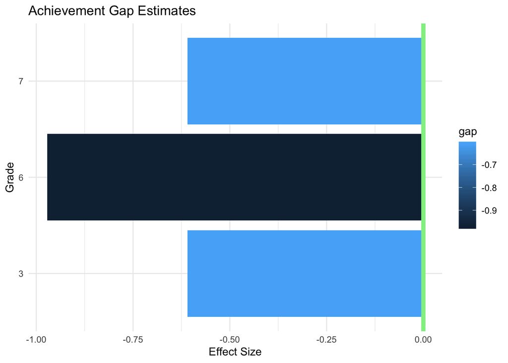

```
##
## $`Aloha High School`
```

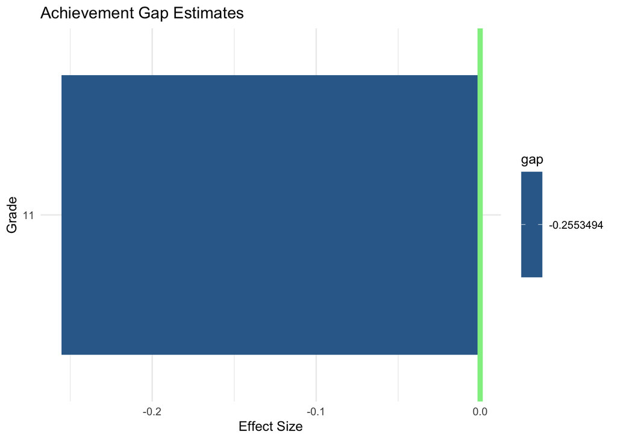

```
##
## $`Aloha-Huber Park School`
```

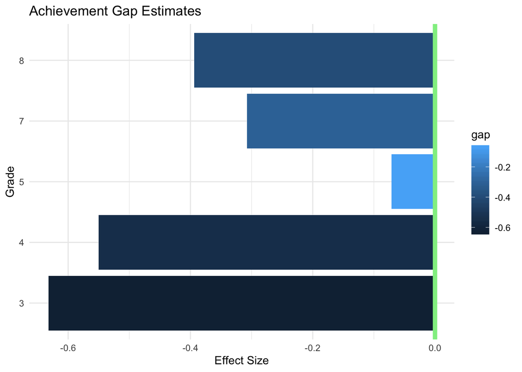

```
##
## $`Amity Elementary School`
```

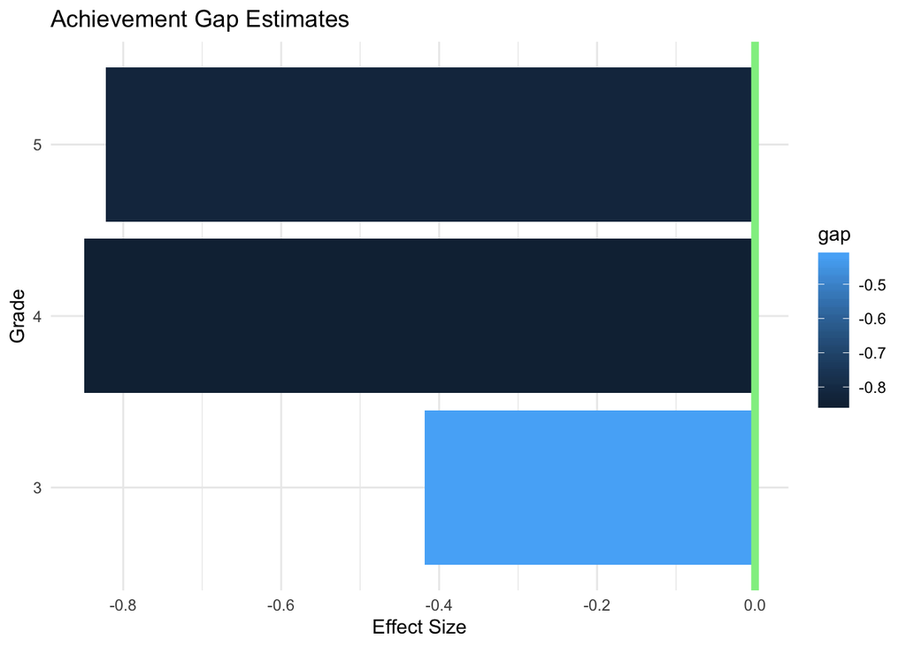

```
##
## $`Amity Middle School`
```

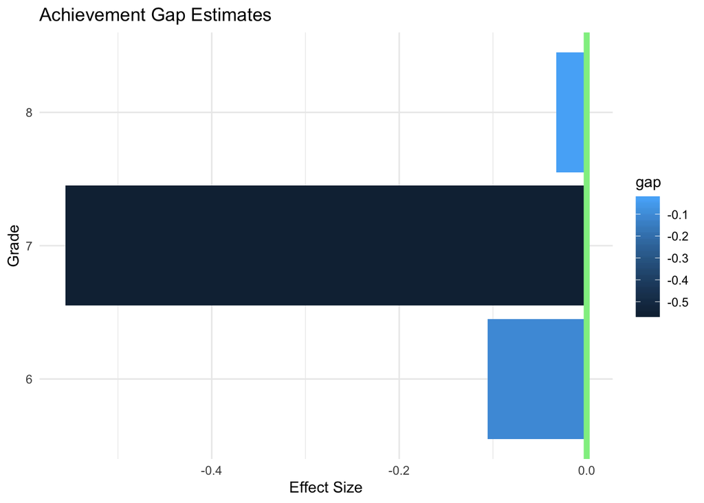

```
##
## $`Arco Iris Spanish Immersion School`
```

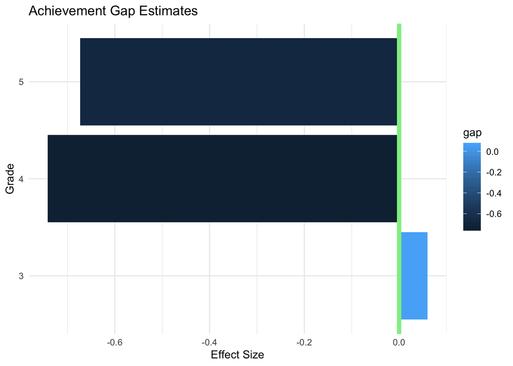

```
##
## $`Arts and Communication Magnet Academy`
```

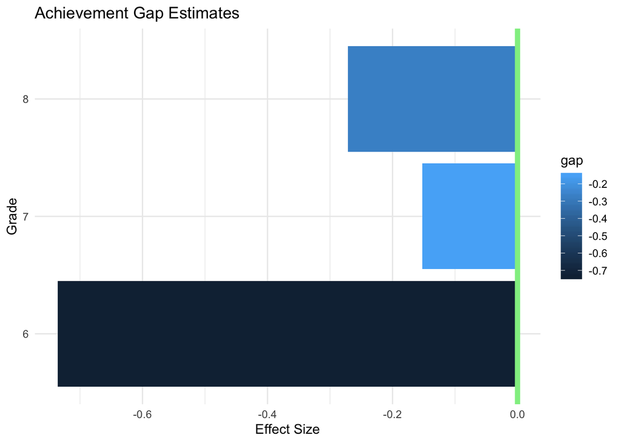

```
##
## $`Ashland High School`
```

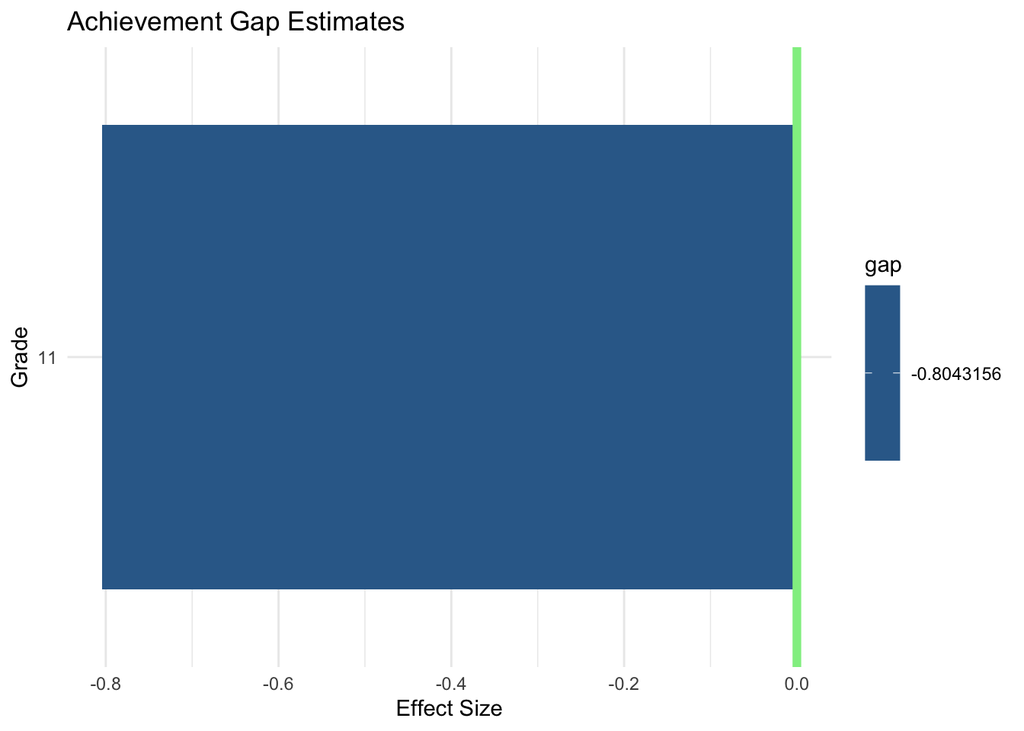

```
##
## $`Ashland Middle School`
```

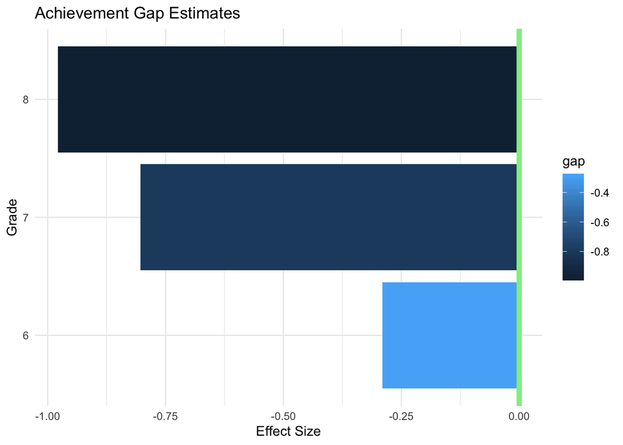

```
##
## $`Astoria Middle School`
```

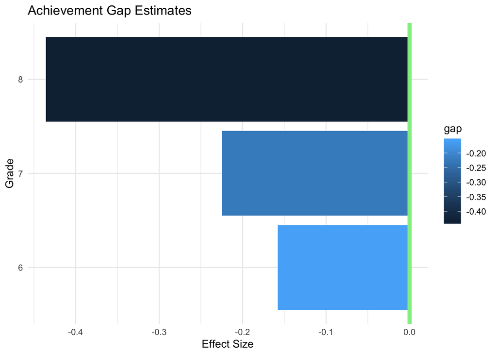

```
##
## $`Astoria Senior High School`
```

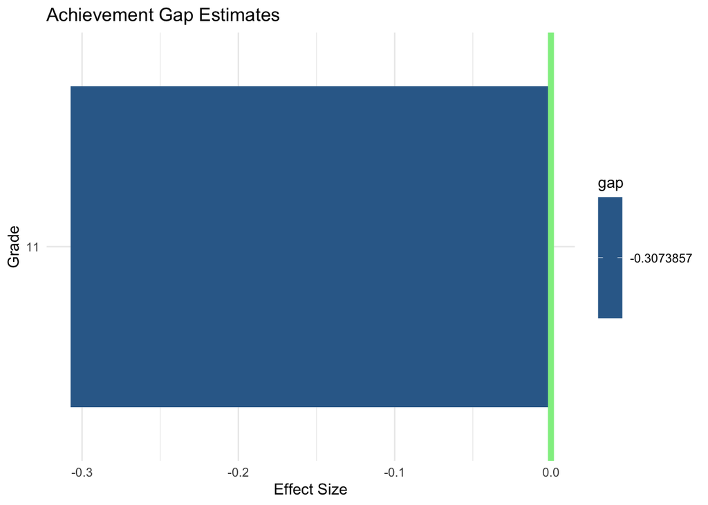

```
##
## $`Athena Elementary School`
```

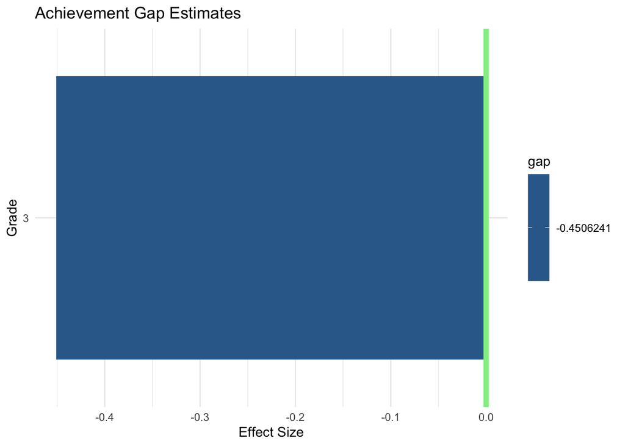

```
##
## $`Baker Middle School`
```

[31 more figures not shown]

```r
lapply(gaps, function(x) {
    ggplot(x, aes(grade_level, gap, fill = gap)) +
    geom_bar(stat = "identity") +
    geom_hline(yintercept = 0, color = "light green", size = 2) +
    coord_flip() +
    theme_minimal() +
    labs(x = "Grade", y = "Effect Size", title = "Achievement Gap Estimates")
})
```

3. Save the plots into a “plots” directory. Make sure the file names are meaningful.